# Missing Data

## Dealing with Missing Data

## Missing data types

One of the most important aspects of data cleaning is missing values.

Types of “missing” data:

- `NA` - general missing data
- `NaN` - stands for “**N**ot **a** **N**umber”, happens when you do 0/0.
- `Inf` and `-Inf` - Infinity, happens when you take a positive number (or negative number) by 0.

## Missing Data with Logicals

Logical operations return `NA` for `NA` values. Think about it, the data could be `> 2` or not we don’t know, so `R` says there is no `TRUE` or `FALSE`, so that is missing:

```r
x <- c(0, NA, 2, 3, 4)
x > 2
```

```
[1] FALSE    NA FALSE  TRUE  TRUE
```

## Missing Data Issues

Mathematical operations with `NA` result in `NA`s.

```r
y <- c(1,2,3,NA)
sum(y)
```

```
[1] NA
```

```r
mean(y)
```

```
[1] NA
```

## Missing Data Issues

Logicals: `TRUE` is evaluated as 1 and `FALSE` is evaluated as 0.

```r
x <- c(TRUE, TRUE, TRUE, TRUE, FALSE, NA)
sum(x)
```

```
[1] NA
```

```r
sum(x, na.rm = TRUE)
```

```
[1] 4
```

## Finding Missing data

- `is.na` - looks for `NAN` and `NA`
- `is.nan`- looks for `NAN`

```r
test <- c(0,NA, -1, NaN)
is.na(test)
```

```
[1] FALSE  TRUE FALSE  TRUE
```

```r
is.nan(test)
```

```
[1] FALSE FALSE FALSE  TRUE
```

## Useful checking functions

Do we have any `NA`s? (`any` can help)

```r
A <- c(1, 2, 3, NA)
B <- c(1, 2, 3, 4)
```

```r
any(is.na(A)) # are there any NAs - YES/TRUE
```

```
[1] TRUE
```

```r
any(is.na(B)) # are there any NAs- NO/FALSE
```

```
[1] FALSE
```

## Finding `NA` values with `count()`

Check the values for your variables, are they what you expect?

`count()` is a great option because it gives you:

1. The unique values
2. The amount of these values

Check if rare values make sense.

## Finding `NA` values with `count()`

```r
library(readr)
bike <-read_csv("https://sisbid.github.io/Data-Wrangling/labs/Bike_Lanes.csv")
count(bike, subType)
```

```
# A tibble: 4 × 2
  subType     n
  <chr>   <int>
1 STCLN       1
2 STRALY      3
3 STRPRD   1623
4 <NA>        4
```

## `naniar`

Sometimes you need to look at lots of data… the [`naniar` package](https://cran.r-project.org/web/packages/naniar/vignettes/getting-started-w-naniar.html) is a good option.

```r
#install.packages("naniar")
library(naniar)
```

## Air quality data

The `airquality` dataset comes with R about air quality in New York in 1973.

```r
?airquality # use this to find out more about the data
```

## naniar: `pct_complete()`

This can tell you if there are missing values in the dataset.

```r
pct_complete(airquality)
```

```
[1] 95.20697
```

Or for a particular variable:

```r
airquality %>% select(Ozone) %>%
pct_complete()
```

```
[1] 75.81699
```

## naniar:`miss_var_summary()`

To get the percent missing (and counts) for each variable as a table, use this function.

```r
miss_var_summary(airquality)
```

```
# A tibble: 6 × 3
  variable n_miss pct_miss
  <chr>     <int>    <num>
1 Ozone        37    24.2
2 Solar.R       7     4.58
3 Wind          0     0
4 Temp          0     0
5 Month         0     0
6 Day           0     0
```

## `miss_case_summary` which rows (IDs) have missing data

```r
miss_case_summary(airquality)
```

```
# A tibble: 153 × 3
    case n_miss pct_miss
   <int>  <int>    <dbl>
 1     5      2     33.3
 2    27      2     33.3
 3     6      1     16.7
 4    10      1     16.7
 5    11      1     16.7
 6    25      1     16.7
 7    26      1     16.7
 8    32      1     16.7
 9    33      1     16.7
10    34      1     16.7
# ℹ 143 more rows
```

## `naniar` plots

The `gg_miss_var()` function creates a nice plot about the number of missing values for each variable, (need a data frame).

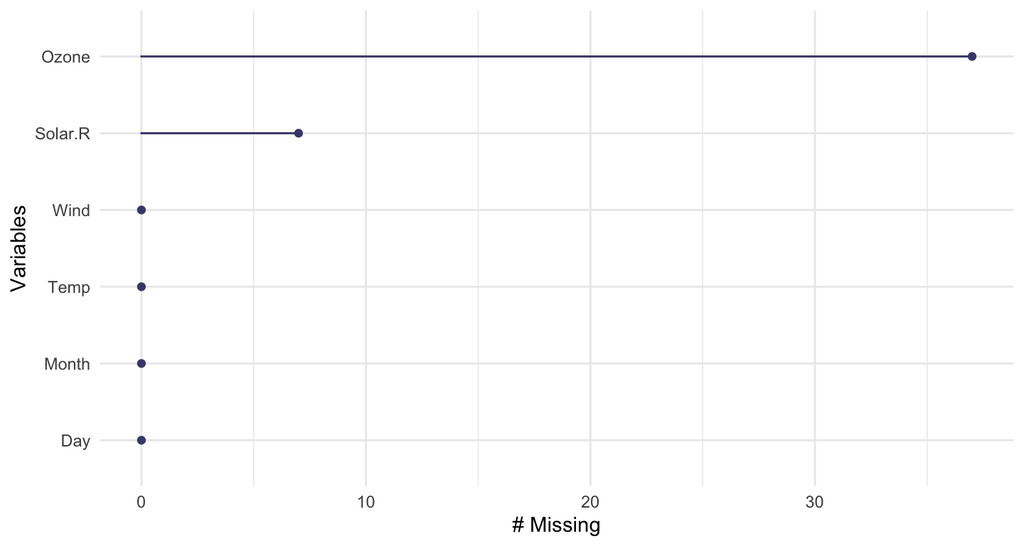

```r
gg_miss_var(airquality)
```

## filter() and missing data

Be **careful** with missing data using subsetting!

**`filter()` removes missing values by default.** Because R can’t tell for sure if an `NA` value meets the condition. To keep them need to add `is.na()` conditional.

Think about if this is OK or not - it depends on your data!

## filter() and missing data

What if NA values represent values that are so low it is undetectable?

Filter will drop them from the data.

```r
airquality %>% filter(Ozone < 5)
```

```
  Ozone Solar.R Wind Temp Month Day
1     1       8  9.7   59     5  21
2     4      25  9.7   61     5  23
```

## filter() and missing data

`is.na()` can help us keep them.

```r
airquality %>% filter(Ozone < 5 | is.na(Ozone))
```

```
   Ozone Solar.R Wind Temp Month Day
1     NA      NA 14.3   56     5   5
2     NA     194  8.6   69     5  10
3      1       8  9.7   59     5  21
4      4      25  9.7   61     5  23
5     NA      66 16.6   57     5  25
6     NA     266 14.9   58     5  26
7     NA      NA  8.0   57     5  27
8     NA     286  8.6   78     6   1
9     NA     287  9.7   74     6   2
10    NA     242 16.1   67     6   3
11    NA     186  9.2   84     6   4
12    NA     220  8.6   85     6   5
13    NA     264 14.3   79     6   6
14    NA     273  6.9   87     6   8
15    NA     259 10.9   93     6  11
16    NA     250  9.2   92     6  12
17    NA     332 13.8   80     6  14
18    NA     322 11.5   79     6  15
19    NA     150  6.3   77     6  21
20    NA      59  1.7   76     6  22
21    NA      91  4.6   76     6  23
22    NA     250  6.3   76     6  24
23    NA     135  8.0   75     6  25
24    NA     127  8.0   78     6  26
25    NA      47 10.3   73     6  27
26    NA      98 11.5   80     6  28
27    NA      31 14.9   77     6  29
28    NA     138  8.0   83     6  30
29    NA     101 10.9   84     7   4
30    NA     139  8.6   82     7  11
31    NA     291 14.9   91     7  14
32    NA     258  9.7   81     7  22
33    NA     295 11.5   82     7  23
34    NA     222  8.6   92     8  10
35    NA     137 11.5   86     8  11
36    NA      64 11.5   79     8  15
37    NA     255 12.6   75     8  23
38    NA     153  5.7   88     8  27
39    NA     145 13.2   77     9  27
```

## To remove **rows** with `NA` values for a **variable** use `drop_na()`

A function from the `tidyr` package. (Need a data frame to start!)

Disclaimer: Don’t do this unless you have thought about if dropping `NA` values makes sense based on knowing what these values mean in your data.

```r
airquality
```

```
    Ozone Solar.R Wind Temp Month Day
1      41     190  7.4   67     5   1
2      36     118  8.0   72     5   2
3      12     149 12.6   74     5   3
4      18     313 11.5   62     5   4
5      NA      NA 14.3   56     5   5
6      28      NA 14.9   66     5   6
7      23     299  8.6   65     5   7
8      19      99 13.8   59     5   8
9       8      19 20.1   61     5   9
10     NA     194  8.6   69     5  10
11      7      NA  6.9   74     5  11
12     16     256  9.7   69     5  12
13     11     290  9.2   66     5  13
14     14     274 10.9   68     5  14
15     18      65 13.2   58     5  15
16     14     334 11.5   64     5  16
17     34     307 12.0   66     5  17
18      6      78 18.4   57     5  18
19     30     322 11.5   68     5  19
20     11      44  9.7   62     5  20
21      1       8  9.7   59     5  21
22     11     320 16.6   73     5  22
23      4      25  9.7   61     5  23
24     32      92 12.0   61     5  24
25     NA      66 16.6   57     5  25
26     NA     266 14.9   58     5  26
27     NA      NA  8.0   57     5  27
28     23      13 12.0   67     5  28
29     45     252 14.9   81     5  29
30    115     223  5.7   79     5  30
31     37     279  7.4   76     5  31
32     NA     286  8.6   78     6   1
33     NA     287  9.7   74     6   2
34     NA     242 16.1   67     6   3
35     NA     186  9.2   84     6   4
36     NA     220  8.6   85     6   5
37     NA     264 14.3   79     6   6
38     29     127  9.7   82     6   7
39     NA     273  6.9   87     6   8
40     71     291 13.8   90     6   9
41     39     323 11.5   87     6  10
42     NA     259 10.9   93     6  11
43     NA     250  9.2   92     6  12
44     23     148  8.0   82     6  13
45     NA     332 13.8   80     6  14
46     NA     322 11.5   79     6  15
47     21     191 14.9   77     6  16
48     37     284 20.7   72     6  17
49     20      37  9.2   65     6  18
50     12     120 11.5   73     6  19
51     13     137 10.3   76     6  20
52     NA     150  6.3   77     6  21
53     NA      59  1.7   76     6  22
54     NA      91  4.6   76     6  23
55     NA     250  6.3   76     6  24
56     NA     135  8.0   75     6  25
57     NA     127  8.0   78     6  26
58     NA      47 10.3   73     6  27
59     NA      98 11.5   80     6  28
60     NA      31 14.9   77     6  29
61     NA     138  8.0   83     6  30
62    135     269  4.1   84     7   1
63     49     248  9.2   85     7   2
64     32     236  9.2   81     7   3
65     NA     101 10.9   84     7   4
66     64     175  4.6   83     7   5
67     40     314 10.9   83     7   6
68     77     276  5.1   88     7   7
69     97     267  6.3   92     7   8
70     97     272  5.7   92     7   9
71     85     175  7.4   89     7  10
72     NA     139  8.6   82     7  11
73     10     264 14.3   73     7  12
74     27     175 14.9   81     7  13
75     NA     291 14.9   91     7  14
76      7      48 14.3   80     7  15
77     48     260  6.9   81     7  16
78     35     274 10.3   82     7  17
79     61     285  6.3   84     7  18
80     79     187  5.1   87     7  19
81     63     220 11.5   85     7  20
82     16       7  6.9   74     7  21
83     NA     258  9.7   81     7  22
84     NA     295 11.5   82     7  23
85     80     294  8.6   86     7  24
86    108     223  8.0   85     7  25
87     20      81  8.6   82     7  26
88     52      82 12.0   86     7  27
89     82     213  7.4   88     7  28
90     50     275  7.4   86     7  29
91     64     253  7.4   83     7  30
92     59     254  9.2   81     7  31
93     39      83  6.9   81     8   1
94      9      24 13.8   81     8   2
95     16      77  7.4   82     8   3
96     78      NA  6.9   86     8   4
97     35      NA  7.4   85     8   5
98     66      NA  4.6   87     8   6
99    122     255  4.0   89     8   7
100    89     229 10.3   90     8   8
101   110     207  8.0   90     8   9
102    NA     222  8.6   92     8  10
103    NA     137 11.5   86     8  11
104    44     192 11.5   86     8  12
105    28     273 11.5   82     8  13
106    65     157  9.7   80     8  14
107    NA      64 11.5   79     8  15
108    22      71 10.3   77     8  16
109    59      51  6.3   79     8  17
110    23     115  7.4   76     8  18
111    31     244 10.9   78     8  19
112    44     190 10.3   78     8  20
113    21     259 15.5   77     8  21
114     9      36 14.3   72     8  22
115    NA     255 12.6   75     8  23
116    45     212  9.7   79     8  24
117   168     238  3.4   81     8  25
118    73     215  8.0   86     8  26
119    NA     153  5.7   88     8  27
120    76     203  9.7   97     8  28
121   118     225  2.3   94     8  29
122    84     237  6.3   96     8  30
123    85     188  6.3   94     8  31
124    96     167  6.9   91     9   1
125    78     197  5.1   92     9   2
126    73     183  2.8   93     9   3
127    91     189  4.6   93     9   4
128    47      95  7.4   87     9   5
129    32      92 15.5   84     9   6
130    20     252 10.9   80     9   7
131    23     220 10.3   78     9   8
132    21     230 10.9   75     9   9
133    24     259  9.7   73     9  10
134    44     236 14.9   81     9  11
135    21     259 15.5   76     9  12
136    28     238  6.3   77     9  13
137     9      24 10.9   71     9  14
138    13     112 11.5   71     9  15
139    46     237  6.9   78     9  16
140    18     224 13.8   67     9  17
141    13      27 10.3   76     9  18
142    24     238 10.3   68     9  19
143    16     201  8.0   82     9  20
144    13     238 12.6   64     9  21
145    23      14  9.2   71     9  22
146    36     139 10.3   81     9  23
147     7      49 10.3   69     9  24
148    14      20 16.6   63     9  25
149    30     193  6.9   70     9  26
150    NA     145 13.2   77     9  27
151    14     191 14.3   75     9  28
152    18     131  8.0   76     9  29
153    20     223 11.5   68     9  30
```

## To remove **rows** with `NA` values for a **variable** use `drop_na()`

```r
airquality %>% drop_na(Ozone)
```

```
    Ozone Solar.R Wind Temp Month Day
1      41     190  7.4   67     5   1
2      36     118  8.0   72     5   2
3      12     149 12.6   74     5   3
4      18     313 11.5   62     5   4
5      28      NA 14.9   66     5   6
6      23     299  8.6   65     5   7
7      19      99 13.8   59     5   8
8       8      19 20.1   61     5   9
9       7      NA  6.9   74     5  11
10     16     256  9.7   69     5  12
11     11     290  9.2   66     5  13
12     14     274 10.9   68     5  14
13     18      65 13.2   58     5  15
14     14     334 11.5   64     5  16
15     34     307 12.0   66     5  17
16      6      78 18.4   57     5  18
17     30     322 11.5   68     5  19
18     11      44  9.7   62     5  20
19      1       8  9.7   59     5  21
20     11     320 16.6   73     5  22
21      4      25  9.7   61     5  23
22     32      92 12.0   61     5  24
23     23      13 12.0   67     5  28
24     45     252 14.9   81     5  29
25    115     223  5.7   79     5  30
26     37     279  7.4   76     5  31
27     29     127  9.7   82     6   7
28     71     291 13.8   90     6   9
29     39     323 11.5   87     6  10
30     23     148  8.0   82     6  13
31     21     191 14.9   77     6  16
32     37     284 20.7   72     6  17
33     20      37  9.2   65     6  18
34     12     120 11.5   73     6  19
35     13     137 10.3   76     6  20
36    135     269  4.1   84     7   1
37     49     248  9.2   85     7   2
38     32     236  9.2   81     7   3
39     64     175  4.6   83     7   5
40     40     314 10.9   83     7   6
41     77     276  5.1   88     7   7
42     97     267  6.3   92     7   8
43     97     272  5.7   92     7   9
44     85     175  7.4   89     7  10
45     10     264 14.3   73     7  12
46     27     175 14.9   81     7  13
47      7      48 14.3   80     7  15
48     48     260  6.9   81     7  16
49     35     274 10.3   82     7  17
50     61     285  6.3   84     7  18
51     79     187  5.1   87     7  19
52     63     220 11.5   85     7  20
53     16       7  6.9   74     7  21
54     80     294  8.6   86     7  24
55    108     223  8.0   85     7  25
56     20      81  8.6   82     7  26
57     52      82 12.0   86     7  27
58     82     213  7.4   88     7  28
59     50     275  7.4   86     7  29
60     64     253  7.4   83     7  30
61     59     254  9.2   81     7  31
62     39      83  6.9   81     8   1
63      9      24 13.8   81     8   2
64     16      77  7.4   82     8   3
65     78      NA  6.9   86     8   4
66     35      NA  7.4   85     8   5
67     66      NA  4.6   87     8   6
68    122     255  4.0   89     8   7
69     89     229 10.3   90     8   8
70    110     207  8.0   90     8   9
71     44     192 11.5   86     8  12
72     28     273 11.5   82     8  13
73     65     157  9.7   80     8  14
74     22      71 10.3   77     8  16
75     59      51  6.3   79     8  17
76     23     115  7.4   76     8  18
77     31     244 10.9   78     8  19
78     44     190 10.3   78     8  20
79     21     259 15.5   77     8  21
80      9      36 14.3   72     8  22
81     45     212  9.7   79     8  24
82    168     238  3.4   81     8  25
83     73     215  8.0   86     8  26
84     76     203  9.7   97     8  28
85    118     225  2.3   94     8  29
86     84     237  6.3   96     8  30
87     85     188  6.3   94     8  31
88     96     167  6.9   91     9   1
89     78     197  5.1   92     9   2
90     73     183  2.8   93     9   3
91     91     189  4.6   93     9   4
92     47      95  7.4   87     9   5
93     32      92 15.5   84     9   6
94     20     252 10.9   80     9   7
95     23     220 10.3   78     9   8
96     21     230 10.9   75     9   9
97     24     259  9.7   73     9  10
98     44     236 14.9   81     9  11
99     21     259 15.5   76     9  12
100    28     238  6.3   77     9  13
101     9      24 10.9   71     9  14
102    13     112 11.5   71     9  15
103    46     237  6.9   78     9  16
104    18     224 13.8   67     9  17
105    13      27 10.3   76     9  18
106    24     238 10.3   68     9  19
107    16     201  8.0   82     9  20
108    13     238 12.6   64     9  21
109    23      14  9.2   71     9  22
110    36     139 10.3   81     9  23
111     7      49 10.3   69     9  24
112    14      20 16.6   63     9  25
113    30     193  6.9   70     9  26
114    14     191 14.3   75     9  28
115    18     131  8.0   76     9  29
116    20     223 11.5   68     9  30
```

## Drop all NAs with `drop_na()`

Drops rows with **any** missing data in **any** column.

```r
airquality %>% drop_na()
```

```
    Ozone Solar.R Wind Temp Month Day
1      41     190  7.4   67     5   1
2      36     118  8.0   72     5   2
3      12     149 12.6   74     5   3
4      18     313 11.5   62     5   4
5      23     299  8.6   65     5   7
6      19      99 13.8   59     5   8
7       8      19 20.1   61     5   9
8      16     256  9.7   69     5  12
9      11     290  9.2   66     5  13
10     14     274 10.9   68     5  14
11     18      65 13.2   58     5  15
12     14     334 11.5   64     5  16
13     34     307 12.0   66     5  17
14      6      78 18.4   57     5  18
15     30     322 11.5   68     5  19
16     11      44  9.7   62     5  20
17      1       8  9.7   59     5  21
18     11     320 16.6   73     5  22
19      4      25  9.7   61     5  23
20     32      92 12.0   61     5  24
21     23      13 12.0   67     5  28
22     45     252 14.9   81     5  29
23    115     223  5.7   79     5  30
24     37     279  7.4   76     5  31
25     29     127  9.7   82     6   7
26     71     291 13.8   90     6   9
27     39     323 11.5   87     6  10
28     23     148  8.0   82     6  13
29     21     191 14.9   77     6  16
30     37     284 20.7   72     6  17
31     20      37  9.2   65     6  18
32     12     120 11.5   73     6  19
33     13     137 10.3   76     6  20
34    135     269  4.1   84     7   1
35     49     248  9.2   85     7   2
36     32     236  9.2   81     7   3
37     64     175  4.6   83     7   5
38     40     314 10.9   83     7   6
39     77     276  5.1   88     7   7
40     97     267  6.3   92     7   8
41     97     272  5.7   92     7   9
42     85     175  7.4   89     7  10
43     10     264 14.3   73     7  12
44     27     175 14.9   81     7  13
45      7      48 14.3   80     7  15
46     48     260  6.9   81     7  16
47     35     274 10.3   82     7  17
48     61     285  6.3   84     7  18
49     79     187  5.1   87     7  19
50     63     220 11.5   85     7  20
51     16       7  6.9   74     7  21
52     80     294  8.6   86     7  24
53    108     223  8.0   85     7  25
54     20      81  8.6   82     7  26
55     52      82 12.0   86     7  27
56     82     213  7.4   88     7  28
57     50     275  7.4   86     7  29
58     64     253  7.4   83     7  30
59     59     254  9.2   81     7  31
60     39      83  6.9   81     8   1
61      9      24 13.8   81     8   2
62     16      77  7.4   82     8   3
63    122     255  4.0   89     8   7
64     89     229 10.3   90     8   8
65    110     207  8.0   90     8   9
66     44     192 11.5   86     8  12
67     28     273 11.5   82     8  13
68     65     157  9.7   80     8  14
69     22      71 10.3   77     8  16
70     59      51  6.3   79     8  17
71     23     115  7.4   76     8  18
72     31     244 10.9   78     8  19
73     44     190 10.3   78     8  20
74     21     259 15.5   77     8  21
75      9      36 14.3   72     8  22
76     45     212  9.7   79     8  24
77    168     238  3.4   81     8  25
78     73     215  8.0   86     8  26
79     76     203  9.7   97     8  28
80    118     225  2.3   94     8  29
81     84     237  6.3   96     8  30
82     85     188  6.3   94     8  31
83     96     167  6.9   91     9   1
84     78     197  5.1   92     9   2
85     73     183  2.8   93     9   3
86     91     189  4.6   93     9   4
87     47      95  7.4   87     9   5
88     32      92 15.5   84     9   6
89     20     252 10.9   80     9   7
90     23     220 10.3   78     9   8
91     21     230 10.9   75     9   9
92     24     259  9.7   73     9  10
93     44     236 14.9   81     9  11
94     21     259 15.5   76     9  12
95     28     238  6.3   77     9  13
96      9      24 10.9   71     9  14
97     13     112 11.5   71     9  15
98     46     237  6.9   78     9  16
99     18     224 13.8   67     9  17
100    13      27 10.3   76     9  18
101    24     238 10.3   68     9  19
102    16     201  8.0   82     9  20
103    13     238 12.6   64     9  21
104    23      14  9.2   71     9  22
105    36     139 10.3   81     9  23
106     7      49 10.3   69     9  24
107    14      20 16.6   63     9  25
108    30     193  6.9   70     9  26
109    14     191 14.3   75     9  28
110    18     131  8.0   76     9  29
111    20     223 11.5   68     9  30
```

## Drop **columns** with any missing values

Use the `miss_var_which()` function from `naniar`

```r
miss_var_which(airquality) # which columns have missing values
```

```
[1] "Ozone"   "Solar.R"
```

## Drop **columns** with any missing values

`miss_var_which` and function from `naniar` (need a data frame)

```r
airquality %>% select(!miss_var_which(airquality))
```

```
    Wind Temp Month Day
1    7.4   67     5   1
2    8.0   72     5   2
3   12.6   74     5   3
4   11.5   62     5   4
5   14.3   56     5   5
6   14.9   66     5   6
7    8.6   65     5   7
8   13.8   59     5   8
9   20.1   61     5   9
10   8.6   69     5  10
11   6.9   74     5  11
12   9.7   69     5  12
13   9.2   66     5  13
14  10.9   68     5  14
15  13.2   58     5  15
16  11.5   64     5  16
17  12.0   66     5  17
18  18.4   57     5  18
19  11.5   68     5  19
20   9.7   62     5  20
21   9.7   59     5  21
22  16.6   73     5  22
23   9.7   61     5  23
24  12.0   61     5  24
25  16.6   57     5  25
26  14.9   58     5  26
27   8.0   57     5  27
28  12.0   67     5  28
29  14.9   81     5  29
30   5.7   79     5  30
31   7.4   76     5  31
32   8.6   78     6   1
33   9.7   74     6   2
34  16.1   67     6   3
35   9.2   84     6   4
36   8.6   85     6   5
37  14.3   79     6   6
38   9.7   82     6   7
39   6.9   87     6   8
40  13.8   90     6   9
41  11.5   87     6  10
42  10.9   93     6  11
43   9.2   92     6  12
44   8.0   82     6  13
45  13.8   80     6  14
46  11.5   79     6  15
47  14.9   77     6  16
48  20.7   72     6  17
49   9.2   65     6  18
50  11.5   73     6  19
51  10.3   76     6  20
52   6.3   77     6  21
53   1.7   76     6  22
54   4.6   76     6  23
55   6.3   76     6  24
56   8.0   75     6  25
57   8.0   78     6  26
58  10.3   73     6  27
59  11.5   80     6  28
60  14.9   77     6  29
61   8.0   83     6  30
62   4.1   84     7   1
63   9.2   85     7   2
64   9.2   81     7   3
65  10.9   84     7   4
66   4.6   83     7   5
67  10.9   83     7   6
68   5.1   88     7   7
69   6.3   92     7   8
70   5.7   92     7   9
71   7.4   89     7  10
72   8.6   82     7  11
73  14.3   73     7  12
74  14.9   81     7  13
75  14.9   91     7  14
76  14.3   80     7  15
77   6.9   81     7  16
78  10.3   82     7  17
79   6.3   84     7  18
80   5.1   87     7  19
81  11.5   85     7  20
82   6.9   74     7  21
83   9.7   81     7  22
84  11.5   82     7  23
85   8.6   86     7  24
86   8.0   85     7  25
87   8.6   82     7  26
88  12.0   86     7  27
89   7.4   88     7  28
90   7.4   86     7  29
91   7.4   83     7  30
92   9.2   81     7  31
93   6.9   81     8   1
94  13.8   81     8   2
95   7.4   82     8   3
96   6.9   86     8   4
97   7.4   85     8   5
98   4.6   87     8   6
99   4.0   89     8   7
100 10.3   90     8   8
101  8.0   90     8   9
102  8.6   92     8  10
103 11.5   86     8  11
104 11.5   86     8  12
105 11.5   82     8  13
106  9.7   80     8  14
107 11.5   79     8  15
108 10.3   77     8  16
109  6.3   79     8  17
110  7.4   76     8  18
111 10.9   78     8  19
112 10.3   78     8  20
113 15.5   77     8  21
114 14.3   72     8  22
115 12.6   75     8  23
116  9.7   79     8  24
117  3.4   81     8  25
118  8.0   86     8  26
119  5.7   88     8  27
120  9.7   97     8  28
121  2.3   94     8  29
122  6.3   96     8  30
123  6.3   94     8  31
124  6.9   91     9   1
125  5.1   92     9   2
126  2.8   93     9   3
127  4.6   93     9   4
128  7.4   87     9   5
129 15.5   84     9   6
130 10.9   80     9   7
131 10.3   78     9   8
132 10.9   75     9   9
133  9.7   73     9  10
134 14.9   81     9  11
135 15.5   76     9  12
136  6.3   77     9  13
137 10.9   71     9  14
138 11.5   71     9  15
139  6.9   78     9  16
140 13.8   67     9  17
141 10.3   76     9  18
142 10.3   68     9  19
143  8.0   82     9  20
144 12.6   64     9  21
145  9.2   71     9  22
146 10.3   81     9  23
147 10.3   69     9  24
148 16.6   63     9  25
149  6.9   70     9  26
150 13.2   77     9  27
151 14.3   75     9  28
152  8.0   76     9  29
153 11.5   68     9  30
```

## Change a value to be `NA`

Let’s say we think that all 0 values should be `NA`.

```r
library(readr)
bike <-read_csv("https://sisbid.github.io/Data-Wrangling/labs/Bike_Lanes.csv")
bike <-bike %>% select(type, dateInstalled)
bike
```

```
# A tibble: 1,631 × 2
   type           dateInstalled
   <chr>                  <dbl>
 1 BIKE BOULEVARD             0
 2 SIDEPATH                2010
 3 SIGNED ROUTE            2010
 4 SIDEPATH                   0
 5 BIKE LANE               2011
 6 SIGNED ROUTE            2007
 7 SIGNED ROUTE            2007
 8 SIGNED ROUTE            2007
 9 BIKE LANE               2009
10 SHARROW                 2007
# ℹ 1,621 more rows
```

## Change a value to be `NA`

The `na_if()` function of `dplyr` can be helpful for changing all 0 values to `NA`.

More on `mutate()` soon!

```r
bike %>%
  mutate(dateInstalled = na_if(dateInstalled, 0))
```

```
# A tibble: 1,631 × 2
   type           dateInstalled
   <chr>                  <dbl>
 1 BIKE BOULEVARD            NA
 2 SIDEPATH                2010
 3 SIGNED ROUTE            2010
 4 SIDEPATH                  NA
 5 BIKE LANE               2011
 6 SIGNED ROUTE            2007
 7 SIGNED ROUTE            2007
 8 SIGNED ROUTE            2007
 9 BIKE LANE               2009
10 SHARROW                 2007
# ℹ 1,621 more rows
```

## Change `NA` to be a value

The `replace_na()` function (part of the `tidyr` package), can do the opposite of `na_if()`.

Replacement much match the class of the other values in the column (e.g., character, numeric).

```r
bike %>%
  mutate(dateInstalled = replace_na(dateInstalled, 2005))
```

```
# A tibble: 1,631 × 2
   type           dateInstalled
   <chr>                  <dbl>
 1 BIKE BOULEVARD             0
 2 SIDEPATH                2010
 3 SIGNED ROUTE            2010
 4 SIDEPATH                   0
 5 BIKE LANE               2011
 6 SIGNED ROUTE            2007
 7 SIGNED ROUTE            2007
 8 SIGNED ROUTE            2007
 9 BIKE LANE               2009
10 SHARROW                 2007
# ℹ 1,621 more rows
```

## Think about `NA`

THINK ABOUT YOUR DATA FIRST!

⚠️ Sometimes removing `NA` values leads to distorted math - be careful!

⚠️ Think about what your `NA` means for your data (are you sure ?).

- Is an `NA` for values so low they could not be reported?
- Or is it if it was too low and also if there was a different issue (like no one reported)?

## Think about `NA`

If it is something more like a zero then you might want it included in your data like a zero instead of an `NA`.

Example: - survey reports `NA` if student has never tried cigarettes - survey reports 0 if student has tried cigarettes but did not smoke that week

⚠️ You might want to keep the `NA` values so that you know the original sample size.

## Word of caution - Percentages with `NA`

```r
count(bike, dateInstalled) %>% mutate(percent = (n/(sum(n)) *100))
```

```
# A tibble: 9 × 3
  dateInstalled     n percent
          <dbl> <int>   <dbl>
1             0   126   7.73
2          2006     2   0.123
3          2007   368  22.6
4          2008   206  12.6
5          2009    86   5.27
6          2010   625  38.3
7          2011   101   6.19
8          2012   107   6.56
9          2013    10   0.613
```

## Word of caution - Percentages with `NA`

```r
bike %>% drop_na(dateInstalled) %>%
  count(dateInstalled) %>% mutate(percent = (n/(sum(n)) *100))
```

```
# A tibble: 9 × 3
  dateInstalled     n percent
          <dbl> <int>   <dbl>
1             0   126   7.73
2          2006     2   0.123
3          2007   368  22.6
4          2008   206  12.6
5          2009    86   5.27
6          2010   625  38.3
7          2011   101   6.19
8          2012   107   6.56
9          2013    10   0.613
```

Should you be dividing by the total count with `NA` values included?  
It depends on your data and what `NA` might mean.  
Pay attention to your data and your `NA` values!

## Summary

- `is.na()`,`any(is.na())`, `count()`, and functions from `naniar` like `gg_miss_var()` can help determine if we have `NA` values
- `filter()` automatically removes `NA` values - can’t confirm or deny if condition is met (need `| is.na()` to keep them)
- `drop_na()` can help you remove `NA` values from a variable or an entire data frame
- `NA` values can change your calculation results
- think about what `NA` values represent - don’t drop them if you shouldn’t

https://sisbid.github.io/Data-Wrangling/labs/missing-data-lab.Rmd